# Análise de Questionários do Projeto ‘Meninas na Computação’

Este estudo é uma análise estatística sobre o projeto [Meninas na Computação](http://meninas.cic.unb.br/), coordenado pela professora Dra. Maristela Terto e Holanda et al.

```r
respostas <- read_excel("raw.xlsx", sheet = "unificado", na = "")
respostas$Q1 <- NULL
respostas$Q2 <- NULL
respostas$Serie <- stringr::str_trim(respostas$Serie, side = "both")
respostas <- as.data.frame(lapply(respostas, as.factor))
opcao <- data.frame(Fara_Computacao = levels(respostas$Fara_Computacao), opcao_computacao = c(1, 2, 3))
respostas <- merge(respostas, opcao)
respostas <- respostas[, c(37, 1:36)]
```

Durante os anos de 2011 a 2014, foram entrevistados 3589 alunos do nível fundamental, médio e superior, sobre o curso superior que pretendiam seguir.

O questionário possui 14 questões que foram desmembradas em 36 variáveis.

O primeiro passo do estudo foi recuperar as respostas dos questionários.

O segundo passo envolveu a preparação dos dados. Em primeiro lugar, os questionários foram unificados em uma única tabela, a fim de facilitar a manipulação.

Como o estudo consiste em identificar as motivações das alunas entrevistadas em seguir ou não uma carreira em Ciência da Computação, foram retirados os 0 entrevistados de sexo masculino.

```r
respostas <- subset(respostas, respostas$Sexo == "F")
respostas$Sexo <- NULL
```

São encontradas as seguintes distribuições de série na amostra:

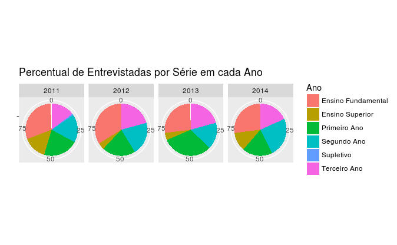

```r
series <- aggregate(x = list(Quantidade = respostas$Serie), by = list(Ano = respostas$Ano, Serie = respostas$Serie), FUN=length)
por_ano <- aggregate(x = list(Total = respostas$Serie), by = list(Ano = respostas$Ano), FUN=length)
series <- merge(series, por_ano)
series$Percentual <- series$Quantidade * 100 / series$Total
p = ggplot(data = series, aes(x = "", y = Percentual, fill = Serie))
p = p + geom_bar(width = 1, stat = "identity")
p = p + facet_grid(facets = . ~ Ano)
p = p + coord_polar(theta = "y", start = 0)
p = p + scale_x_discrete()
p = p + xlab("") + ylab("") + labs(fill="Ano")
p = p + ggtitle("Percentual de Entrevistadas por Série em cada Ano")
p
```

As alunas responderam da seguinte forma sobre a área que gostariam de cursar:

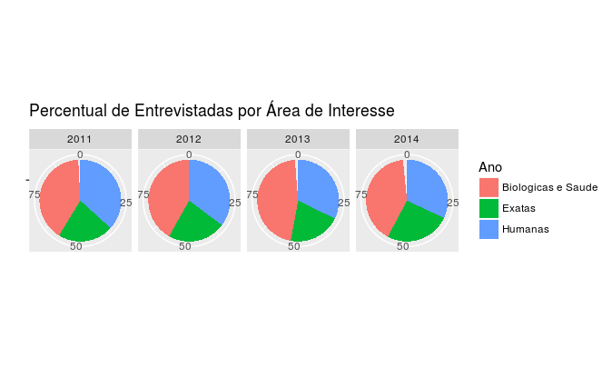

```r
cursos <- aggregate(x = list(Quantidade = respostas$Fara_Curso_Superior), by = list(Ano = respostas$Ano, Fara_Curso_Superior = respostas$Fara_Curso_Superior), FUN=length)
por_ano <- aggregate(x = list(Total = respostas$Fara_Curso_Superior), by = list(Ano = respostas$Ano), FUN=length)
cursos <- merge(cursos, por_ano)
cursos$Percentual <- cursos$Quantidade * 100 / cursos$Total
p = ggplot(data = cursos, aes(x = "", y = Percentual, fill = Fara_Curso_Superior))
p = p + geom_bar(width = 1, stat = "identity")
p = p + facet_grid(facets = . ~ Ano)
p = p + coord_polar(theta = "y", start = 0)
p = p + scale_x_discrete()
p = p + xlab("") + ylab("") + labs(fill="Ano")
p = p + ggtitle("Percentual de Entrevistadas por Área de Interesse")
p
```

A opinião das alunas sobre o cursar Ciência da Computação é representada nos gráficos a seguir:

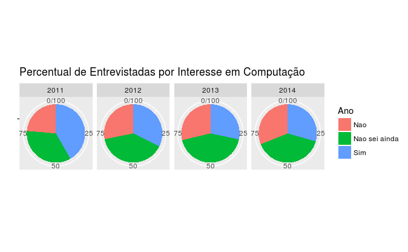

```r
comp <- aggregate(x = list(Quantidade = respostas$Fara_Computacao), by = list(Ano = respostas$Ano, Fara_Computacao = respostas$Fara_Computacao), FUN=length)
por_ano <- aggregate(x = list(Total = respostas$Fara_Computacao), by = list(Ano = respostas$Ano), FUN=length)
comp <- merge(comp, por_ano)
comp$Percentual <- comp$Quantidade * 100 / comp$Total
p = ggplot(data = comp, aes(x = "", y = Percentual, fill = Fara_Computacao))
p = p + geom_bar(width = 1, stat = "identity")
p = p + facet_grid(facets = . ~ Ano)
p = p + coord_polar(theta = "y", start = 0)
p = p + scale_x_discrete()
p = p + xlab("") + ylab("") + labs(fill="Ano")
p = p + ggtitle("Percentual de Entrevistadas por Interesse em Computação")
p
```

Será realizada a seguir uma análise de variância, no intuito de identificar, pergunta a pergunta, se as quantidades médias das respostas são estatisticamente diferentes ou se a diferença identificada nas médias trata-se de ruído.

A análise de variância não será completa sem um teste de comparação de médias: após identificar diferenças reais entre as respostas, será efetuado o teste de Tukey que dirá quais dos itens são diferentes entre si.

Para que seja feita a análise de variância, a amostra deve atender certas pressuposições básicas: 1) os erros são variáveis aleatórias independentes; 2) a variância é constante; 3) a distribuição dos erros é normal ou aproximadamente normal.

Os gráficos que apóiam essas pressuposições serão movidos para o fim da página.

Como exemplo, será efetuada isoladamente a análise de variância do atributo **opcao_computacao** em relação ao atributo **Ano**, com os anos como tratamentos. A variável observada é o interesse do aluno por optar pelo curso de ciência da computação, sendo atribuído o valor 1 no caso em que a estudante respondeu que não fará vestibular para computação, 2 se ainda está em dúvida e 3 se informou que irá optar por computação.

```r
temp <- data.frame(Tratamento = respostas[, 3], Opcao_Computacao = respostas[, 1])
fit <- aov(Opcao_Computacao ~ Tratamento, data = temp)
knit_print(anova(fit))
```

```
Analysis of Variance Table

Response: Opcao_Computacao
             Df Sum Sq Mean Sq F value       Pr(>F)
Tratamento    3     26    8.53      14 0.0000000044 ***
Residuals  3585   2180    0.61
---
Signif. codes:  0 ‘***’ 0.001 ‘**’ 0.01 ‘*’ 0.05 ‘.’ 0.1 ‘ ’ 1
```

```r
cat("\n")
```

```r
knit_print(HSD.test(fit, 'Tratamento'))
```

```
$statistics
  Mean CV MSerror  HSD r.harmonic
   2.1 37    0.61 0.11        659

$parameters
    Df ntr StudentizedRange alpha  test     name.t
  3585   4              3.6  0.05 Tukey Tratamento

$means
     Opcao_Computacao  std    r Min Max
2011              2.2 0.79 1750   1   3
2012              2.0 0.78  926   1   3
2013              2.0 0.76  498   1   3
2014              2.0 0.78  415   1   3

$comparison
NULL

$groups
   trt means M
1 2011   2.2 a
2 2012   2.0 b
3 2013   2.0 b
4 2014   2.0 b
```

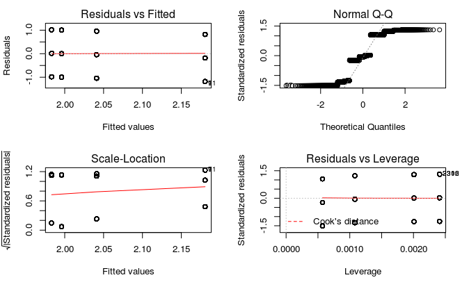

```r
par(mfrow=c(2,2))
plot(fit)
```

```
Tratamento: Serie

Analysis of Variance Table

Response: Opcao_Computacao
             Df Sum Sq Mean Sq F value              Pr(>F)
Tratamento    5    162    32.3    56.8 <0.0000000000000002 ***
Residuals  3533   2013     0.6
---
Signif. codes:  0 ‘***’ 0.001 ‘**’ 0.01 ‘*’ 0.05 ‘.’ 0.1 ‘ ’ 1

$statistics
  Mean CV MSerror  HSD r.harmonic
   2.1 36    0.57 0.32         90

$parameters
    Df ntr StudentizedRange alpha  test     name.t
  3533   6                4  0.05 Tukey Tratamento

$means
                   Opcao_Computacao  std    r Min Max
Ensino Fundamental              2.3 0.72 1073   1   3
Ensino Superior                 1.7 0.81  361   1   3
Primeiro Ano                    2.2 0.75  798   1   3
Segundo Ano                     2.1 0.78  671   1   3
Supletivo                       2.4 0.86   17   1   3
Terceiro Ano                    1.8 0.76  619   1   3

$comparison
NULL

$groups
                 trt means  M
1 Supletivo            2.4  a
2 Ensino Fundamental   2.3  a
3 Primeiro Ano         2.2  a
4 Segundo Ano          2.1  a
5 Terceiro Ano         1.8 ab
6 Ensino Superior      1.7  b

```

[output cut: 19 more lines]

```

$means
                   Opcao_Computacao  std    r Min Max
Biologicas e Saude              2.1 0.79 1450   1   3
Exatas                          2.2 0.78  785   1   3
Humanas                         2.0 0.77 1227   1   3

$comparison
NULL

$groups
                 trt means M
1 Exatas               2.2 a
2 Biologicas e Saude   2.1 b
3 Humanas              2.0 c
```

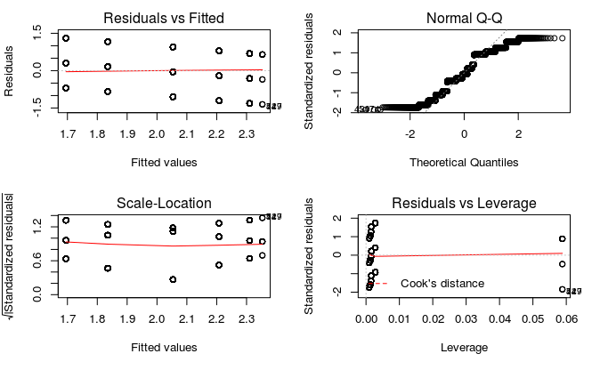

```
Tratamento: Somente_Ensina_Software

Analysis of Variance Table

Response: Opcao_Computacao
             Df Sum Sq Mean Sq F value     Pr(>F)
Tratamento    2     19    9.67    15.9 0.00000014 ***
Residuals  3509   2138    0.61
---
Signif. codes:  0 ‘***’ 0.001 ‘**’ 0.01 ‘*’ 0.05 ‘.’ 0.1 ‘ ’ 1

$statistics
  Mean CV MSerror  HSD r.harmonic
   2.1 37    0.61 0.11        528

$parameters
    Df ntr StudentizedRange alpha  test     name.t
  3509   3              3.3  0.05 Tukey Tratamento

$means
       Opcao_Computacao  std    r Min Max
Nao                 2.1 0.79 2716   1   3
Sim                 2.3 0.77  306   1   3
Talvez              2.1 0.75  490   1   3

$comparison
NULL

$groups
     trt means M
1 Sim      2.3 a
2 Talvez   2.1 b
3 Nao      2.1 b
```

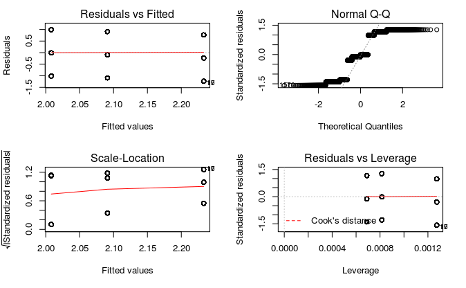

```
Tratamento: Pouca_Matematica

Analysis of Variance Table

Response: Opcao_Computacao
             Df Sum Sq Mean Sq F value              Pr(>F)
Tratamento    2     43    21.3    35.5 0.00000000000000055 ***
Residuals  3481   2089     0.6
---
Signif. codes:  0 ‘***’ 0.001 ‘**’ 0.01 ‘*’ 0.05 ‘.’ 0.1 ‘ ’ 1

$statistics
  Mean CV MSerror   HSD r.harmonic
   2.1 37     0.6 0.088        862

$parameters
    Df ntr StudentizedRange alpha  test     name.t
  3481   3              3.3  0.05 Tukey Tratamento

$means
       Opcao_Computacao  std    r Min Max
Nao                 2.0 0.79 2103   1   3
Sim                 2.3 0.77  559   1   3
Talvez              2.1 0.73  822   1   3

$comparison
NULL

$groups
     trt means M
1 Sim      2.3 a
2 Talvez   2.1 b
3 Nao      2.0 c
```

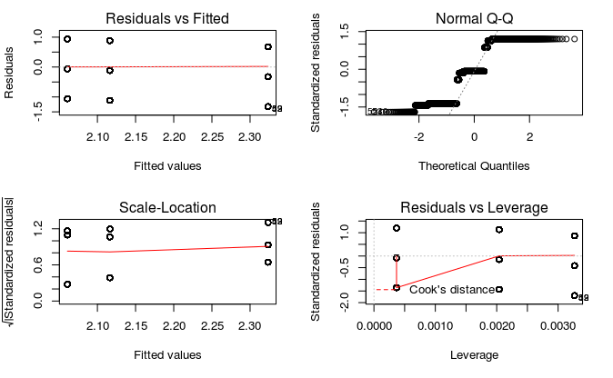

```
Tratamento: Maioria_Homens

Analysis of Variance Table

Response: Opcao_Computacao
             Df Sum Sq Mean Sq F value              Pr(>F)
Tratamento    2     55    27.5      46 <0.0000000000000002 ***
Residuals  3471   2075     0.6
---
Signif. codes:  0 ‘***’ 0.001 ‘**’ 0.01 ‘*’ 0.05 ‘.’ 0.1 ‘ ’ 1

$statistics
  Mean CV MSerror   HSD r.harmonic
   2.1 37     0.6 0.081        992

$parameters
    Df ntr StudentizedRange alpha  test     name.t
  3471   3              3.3  0.05 Tukey Tratamento

$means
       Opcao_Computacao  std    r Min Max
Nao                 2.3 0.75  866   1   3
Sim                 2.0 0.79 1857   1   3
Talvez              2.1 0.76  751   1   3

$comparison
NULL

$groups
     trt means M
1 Nao      2.3 a
2 Talvez   2.1 b
3 Sim      2.0 b
```

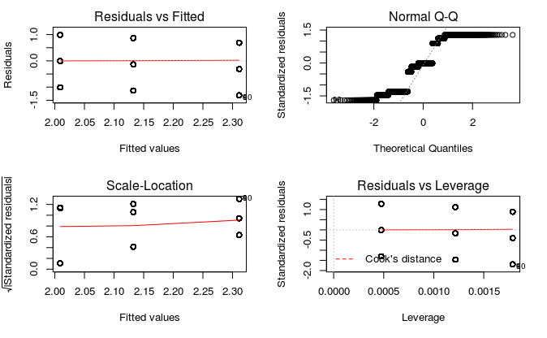

```
Tratamento: Precisa_Saber_Usar_Computador

Analysis of Variance Table

Response: Opcao_Computacao
             Df Sum Sq Mean Sq F value  Pr(>F)
Tratamento    2      9    4.36    7.13 0.00081 ***
Residuals  3468   2119    0.61
---
Signif. codes:  0 ‘***’ 0.001 ‘**’ 0.01 ‘*’ 0.05 ‘.’ 0.1 ‘ ’ 1

$statistics
  Mean CV MSerror   HSD r.harmonic
   2.1 37    0.61 0.081       1033

$parameters
    Df ntr StudentizedRange alpha  test     name.t
  3468   3              3.3  0.05 Tukey Tratamento

$means
       Opcao_Computacao  std    r Min Max
Nao                 2.1 0.79 1072   1   3
Sim                 2.1 0.78 1670   1   3
Talvez              2.0 0.77  729   1   3

$comparison
NULL

$groups
     trt means M
1 Nao      2.1 a
2 Sim      2.1 a
3 Talvez   2.0 b
```

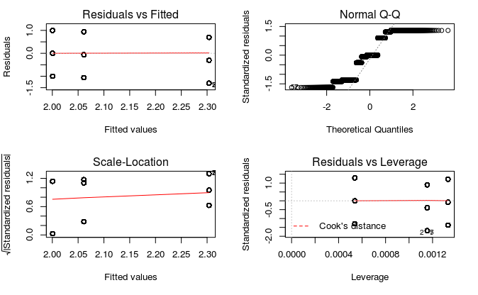

```
Tratamento: Precisa_Curso_Superior

Analysis of Variance Table

Response: Opcao_Computacao
             Df Sum Sq Mean Sq F value              Pr(>F)
Tratamento    2     50    25.1    41.8 <0.0000000000000002 ***
Residuals  3463   2075     0.6
---
Signif. codes:  0 ‘***’ 0.001 ‘**’ 0.01 ‘*’ 0.05 ‘.’ 0.1 ‘ ’ 1

$statistics
  Mean CV MSerror   HSD r.harmonic
   2.1 37     0.6 0.082        977

$parameters
    Df ntr StudentizedRange alpha  test     name.t
  3463   3              3.3  0.05 Tukey Tratamento

$means
       Opcao_Computacao  std    r Min Max
Nao                 1.9 0.80  823   1   3
Sim                 2.2 0.77 1889   1   3
Talvez              2.0 0.74  754   1   3

$comparison
NULL

$groups
     trt means M
1 Sim      2.2 a
2 Talvez   2.0 b
3 Nao      1.9 b
```

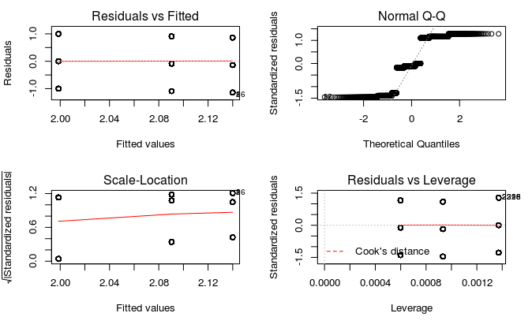

```
Tratamento: Familia_Gostaria_Computacao

Analysis of Variance Table

Response: Opcao_Computacao
             Df Sum Sq Mean Sq F value              Pr(>F)
Tratamento    2    248   124.1     229 <0.0000000000000002 ***
Residuals  3484   1889     0.5
---
Signif. codes:  0 ‘***’ 0.001 ‘**’ 0.01 ‘*’ 0.05 ‘.’ 0.1 ‘ ’ 1

$statistics
  Mean CV MSerror   HSD r.harmonic
   2.1 35    0.54 0.074       1095

$parameters
    Df ntr StudentizedRange alpha  test     name.t
  3484   3              3.3  0.05 Tukey Tratamento

$means
       Opcao_Computacao  std    r Min Max
Nao                 1.8 0.79  999   1   3
Sim                 2.5 0.71  903   1   3
Talvez              2.1 0.72 1585   1   3

$comparison
NULL

$groups
     trt means M
1 Sim      2.5 a
2 Talvez   2.1 b
3 Nao      1.8 c
```

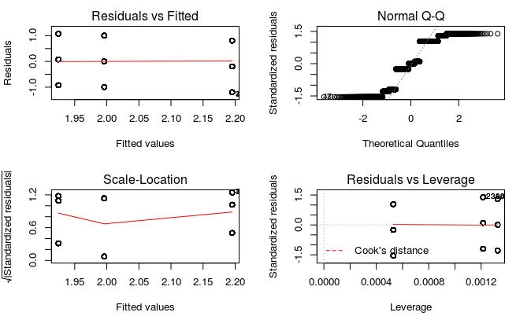

```
Tratamento: Dificuldade_Emprego

Analysis of Variance Table

Response: Opcao_Computacao
             Df Sum Sq Mean Sq F value  Pr(>F)
Tratamento    2      9    4.32    7.07 0.00086 ***
Residuals  3468   2120    0.61
---
Signif. codes:  0 ‘***’ 0.001 ‘**’ 0.01 ‘*’ 0.05 ‘.’ 0.1 ‘ ’ 1

$statistics
  Mean CV MSerror   HSD r.harmonic
   2.1 37    0.61 0.097        709

$parameters
    Df ntr StudentizedRange alpha  test     name.t
  3468   3              3.3  0.05 Tukey Tratamento

$means
       Opcao_Computacao  std    r Min Max
Nao                 2.1 0.79 1955   1   3
Sim                 2.2 0.80  349   1   3
Talvez              2.0 0.77 1167   1   3

$comparison
NULL

$groups
     trt means M
1 Sim      2.2 a
2 Nao      2.1 a
3 Talvez   2.0 b
```

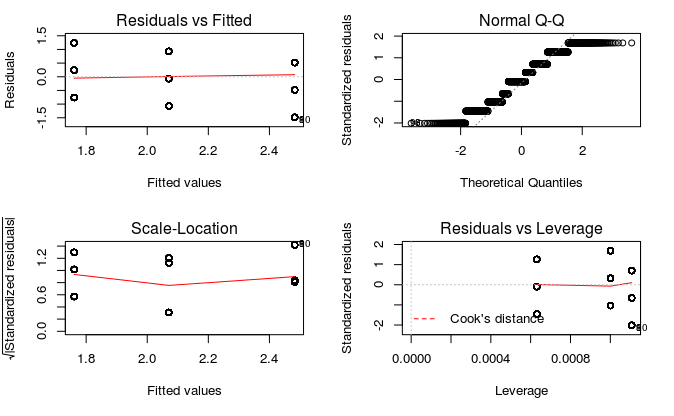

```
Tratamento: Pouco_Lazer

Analysis of Variance Table

Response: Opcao_Computacao
             Df Sum Sq Mean Sq F value  Pr(>F)
Tratamento    2      9    4.44    7.25 0.00072 ***
Residuals  3470   2124    0.61
---
Signif. codes:  0 ‘***’ 0.001 ‘**’ 0.01 ‘*’ 0.05 ‘.’ 0.1 ‘ ’ 1

$statistics
  Mean CV MSerror   HSD r.harmonic
   2.1 37    0.61 0.092        795

$parameters
    Df ntr StudentizedRange alpha  test     name.t
  3470   3              3.3  0.05 Tukey Tratamento

$means
       Opcao_Computacao  std    r Min Max
Nao                 2.1 0.77 1965   1   3
Sim                 2.2 0.81  428   1   3
Talvez              2.0 0.79 1080   1   3

$comparison
NULL

$groups
     trt means M
1 Sim      2.2 a
2 Nao      2.1 a
3 Talvez   2.0 b
```

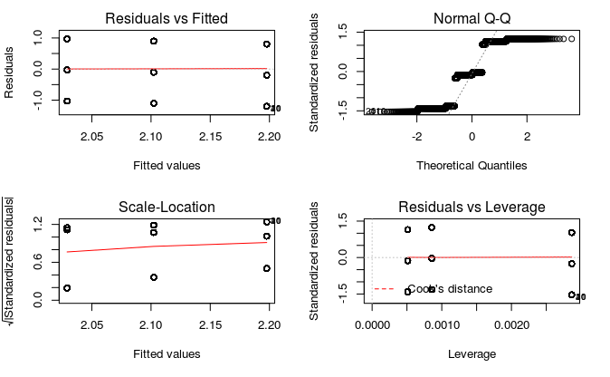

```
Tratamento: Usa_Criatividade

Analysis of Variance Table

Response: Opcao_Computacao
             Df Sum Sq Mean Sq F value Pr(>F)
Tratamento    2      0   0.168    0.27   0.76
Residuals  3471   2135   0.615

$statistics
  Mean CV MSerror  HSD r.harmonic
   2.1 38    0.61 0.14        322

$parameters
    Df ntr StudentizedRange alpha  test     name.t
  3471   3              3.3  0.05 Tukey Tratamento

$means
       Opcao_Computacao  std    r Min Max
Nao                 2.1 0.79  169   1   3
Sim                 2.1 0.78 2978   1   3
Talvez              2.1 0.79  327   1   3

$comparison
NULL

$groups
     trt means M
1 Nao      2.1 a
2 Sim      2.1 a
3 Talvez   2.1 a
```

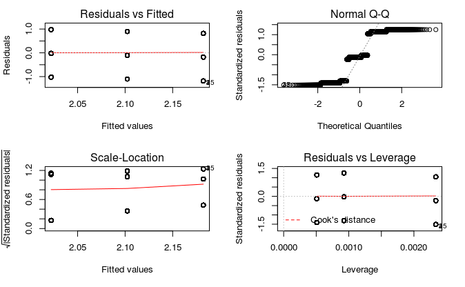

```
Tratamento: Da_Prestigio

Analysis of Variance Table

Response: Opcao_Computacao
             Df Sum Sq Mean Sq F value      Pr(>F)
Tratamento    2     24   11.79    19.4 0.000000004 ***
Residuals  3465   2102    0.61
---
Signif. codes:  0 ‘***’ 0.001 ‘**’ 0.01 ‘*’ 0.05 ‘.’ 0.1 ‘ ’ 1

$statistics
  Mean CV MSerror  HSD r.harmonic
   2.1 37    0.61 0.11        567

$parameters
    Df ntr StudentizedRange alpha  test     name.t
  3465   3              3.3  0.05 Tukey Tratamento

$means
       Opcao_Computacao  std    r Min Max
Nao                 2.1 0.87  258   1   3
Sim                 2.2 0.77 2160   1   3
Talvez              2.0 0.78 1050   1   3

$comparison
NULL

$groups
     trt means  M
1 Sim      2.2  a
2 Nao      2.1 ab
3 Talvez   2.0  b
```

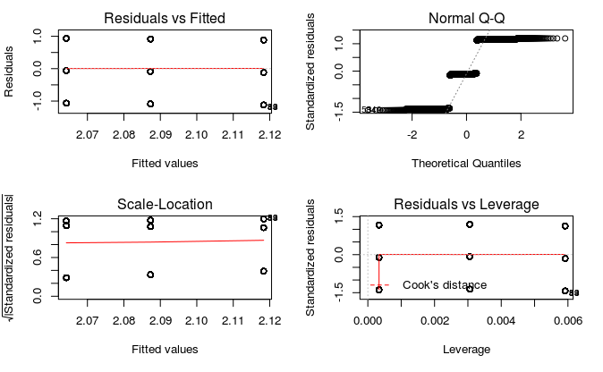

```
Tratamento: Boa_Remuneracao

Analysis of Variance Table

Response: Opcao_Computacao
             Df Sum Sq Mean Sq F value    Pr(>F)
Tratamento    2     16    7.77    12.7 0.0000031 ***
Residuals  3472   2118    0.61
---
Signif. codes:  0 ‘***’ 0.001 ‘**’ 0.01 ‘*’ 0.05 ‘.’ 0.1 ‘ ’ 1

$statistics
  Mean CV MSerror  HSD r.harmonic
   2.1 37    0.61 0.13        406

$parameters
    Df ntr StudentizedRange alpha  test     name.t
  3472   3              3.3  0.05 Tukey Tratamento

$means
       Opcao_Computacao  std    r Min Max
Nao                 2.1 0.79  162   1   3
Sim                 2.2 0.78 1742   1   3
Talvez              2.0 0.78 1571   1   3

$comparison
NULL

$groups
     trt means  M
1 Sim      2.2  a
2 Nao      2.1 ab
3 Talvez   2.0  b
```

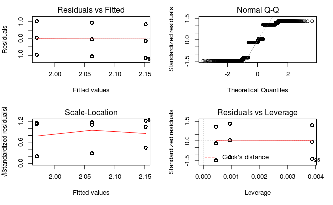

```
Tratamento: Atuacao_Outras_Areas

Analysis of Variance Table

Response: Opcao_Computacao
             Df Sum Sq Mean Sq F value Pr(>F)
Tratamento    2     10    4.79    7.83 0.0004 ***
Residuals  3503   2142    0.61
---
Signif. codes:  0 ‘***’ 0.001 ‘**’ 0.01 ‘*’ 0.05 ‘.’ 0.1 ‘ ’ 1

$statistics
  Mean CV MSerror  HSD r.harmonic
   2.1 37    0.61 0.15        311

$parameters
    Df ntr StudentizedRange alpha  test     name.t
  3503   3              3.3  0.05 Tukey Tratamento

$means
       Opcao_Computacao  std    r Min Max
Nao                 2.1 0.84  127   1   3
Sim                 2.1 0.78 2655   1   3
Talvez              2.0 0.77  724   1   3

$comparison
NULL

$groups
     trt means  M
1 Sim      2.1  a
2 Nao      2.1 ab
3 Talvez   2.0  b
```

[21 more figures not shown]

```r
for (i in 4:ncol(respostas)) {
  temp <- data.frame(Tratamento = respostas[, i], Opcao_Computacao = respostas[, 1])

  nome <- colnames(respostas)[i]
  cat(paste("\nTratamento:", nome, "\n"))
  cat("\n")

  fit <- aov(Opcao_Computacao ~ Tratamento, data = temp)
  knit_print(anova(fit))
  cat("\n")
  knit_print(HSD.test(fit, 'Tratamento'))

  # assign(nome, temp)
  par(mfrow=c(2,2))
  plot(fit)
}
```

A partir do p-valor do tratamento **Ano** (Pr(>F)) abaixo de 5%, há evidências de uma diferença na quantidade de alunas que optam por computação devido à passagem do tempo.

A seguir serão apresentadas as análises de variância dos outros atributos coletados nas entrevistas.

```r
# regras = apriori(data = respostas)
# regras = apriori(data = respostas, parameter = list(minlen=2, supp=0.1, conf=0.8, maxtime=300), appearance = list(rhs = c("Fara_Computacao=Sim", "Fara_Computacao=Nao", "Fara_Computacao=Nao sei ainda"), default="lhs"))
# regras.ordem <- sort(regras, by="lift")
# write(regras.ordem, file="../dados/regras.txt")
```

A partir da análise de variância e do teste de Tukey dos atributos, identificamos o seguinte:

Sobre o atributo **Série**, devemos descartar a informação sobre as estudantes de Supletivo, devido à baixa quantidade de respondentes. Normalmente se descartam tratamentos com menos de 30 ocorrências. Podemos perceber dois grupos: do Ensino Fundamental até o Segundo Ano há uma tendência levemente positiva em relação ao curso de computação; por outro lado, alunas do Terceiro Ano e que já cursam o Nível Superior possuem leve rejeição pelo curso.

Em relação à intenção de fazer um curso superior, atributo **Fara_Curso_Superior**, as estudantes que informaram predileção por Exatas, Biológicas e Saúde possuem uma leve tendência a optar por computação, enquanto as que marcaram Humanas tem dúvida sobre uma carreira em computação.

O atributo **Somente_Ensina_Software** mostra que as estudantes que acreditam em tal afirmação tem tendência a optar por um curso de computação, enquanto as que acreditam no contrário ou não tem certeza ficaram em dúvida sobre cursar computação.

Um dos resultados mais desconcertantes refere-se ao atributo **Pouca_Matematica**: apesar da maioria das entrevistadas acreditar de que o curso de computação baseia-se em muito conteúdo matemático, uma quantidade considerável de respondentes discorda. O elemento contraditório é que estas últimas tem certa tendência em seguir uma carreira em computação!

Outro resultado conflitante está relacionado à afirmação de que nos cursos de computação há muitos homens, atributo **Maioria_Homens**. As entrevistadas que discordam dessa afirmação pretendem cursar ciência da computação.

Sobre o domínio de uso do computador ser um pré-requisito para o curso de computação, atributo **Precisa_Saber_Usar_Computador**, a decisão sobre cursar ou não ciência da computação ficou equilibrada em relação a esse quesito.

O atributo **Precisa_Curso_Superior** está relacionado à necessidade de uma graduação para exercer a profissão de cientista da computação. As estudantes que acreditam nessa afirmativa tem uma leve tendência a optar pelo curso de computação. Já as que não acreditam ou tem dúvida estão indecisas sobre o cursar computação.

O atributo mais marcante neste estudo foi **Familia_Gostaria_Computacao**. Nesse, é possível perceber claramente a influência familiar na decisão do curso superior: estudantes que acreditam que a família ficaria feliz caso elas optassem por computação tem uma forte tendência em realmente escolher o curso. As entrevistadas que acreditam que a família não apoiaria a escolha desse curso tem uma tendência a rejeitar a computação. As que não tem certeza da opinião da família também não tem certeza sobre o desejo de seguir essa carreira.

O atributo **Dificuldade_Emprego**, origina-se da percepção das estudantes de que uma pessoa que trabalha na área de computação tem dificuldades em empregar-se. Houve pouca quantidade de entrevistadas que acreditava nessa afirmação mas, no geral, as estudantes que ficaram indecisas sobre cursar computação.

O atributo **Pouco_Lazer**, originário da pergunta “Quem trabalha com computação tem poucas horas de lazer?”, teve resultados semelhantes ao atributo **Dificuldade_Emprego**, percebendo-se uma forte indecisão na opção do curso, independentemente da percepção de quantidade de lazer.

Os atributos **Usa_Criatividade**, **Da_Prestigio**, **Boa_Remuneracao** e **Atuacao_Outras_Areas** parecem-se muito com os atributos **Dificuldade_Emprego** e **Pouco_Lazer**, denotando que as entrevistadas ainda não preocupam-se com esses atributos na hora de escolher o curso superior.

O atributo **Usa_Computador_Propria_Casa**, que é auto-explicativo, mostra que alunas que não usam ou não possuem o computador em suas casas estão muito propensas a fazer um curso de computação! As estudantes que usam do equipamento em seu domicílio mostram-se indecisas sobre a opção pelo curso.

Os atributos **Usa_Computador_Casa_Parentes** e **Usa_Computacao_Casa_Amigos** tem pouca relevância na decisão por um curso de computação.

O não uso do computador na escola, atributo **Usa_Computador_Escola** gera um efeito inverso, isto é, alunas que não usam o equipamento em aula mostram leve tendência em optar por computação.

Usar ou não usar o computador no trabalho, atributo **Usa_Computador_Trabalho**, parece não ter relevância na escolha do curso de computação.

Usar o computador em uma *Lan House* tem um efeito positivo na opção pelo curso de computação.

Usar ou não usar o computador na biblioteca, atributo **Usa_Computador_Biblioteca**, não tem relevância na opção por cursar computação.

Usar o computador em um *Centro de Inclusão Digital* tem um efeito positivo semelhante a usar em uma *Lan House*, movendo a vontade das alunas para a ciência da computação.

O uso de aplicações de escritório, como *editores de texto*, *planilhas eletrônicas* e *editores de imagens* não tem impacto na escolha do curso de computação.

Contudo, o uso de *banco de dados* e a criação de *programas de computador* tem influência positiva na decisão por cursar ciência da computação.

O **não** uso de *internet*, *redes sociais* e *e-mail* motiva as estudantes a optar pelo curso de computação.

O uso de jogos de computador, atributo **Usa_Jogos**, não tem relevância na escolha do curso de computação.

*Desenvolver páginas web* e *utilizar outros softwares* tem uma pequena relevância na escolha do curso de computação.

```r
# regras = apriori(data = respostas)
# regras = apriori(data = respostas, parameter = list(minlen=2, supp=0.1, conf=0.8, maxtime=300), appearance = list(rhs = c("Fara_Computacao=Sim", "Fara_Computacao=Nao", "Fara_Computacao=Nao sei ainda"), default="lhs"))

# regras.ordem <- sort(regras, by="lift")
# write(regras.ordem, file="../dados/regras.txt")
```